# CIS 546 - Homework Assignment 4

Javier Rojas. jrojas@stu.edu

Due Wednesday 4/12/17 11:59 PM EST

# Graph 1

[figure not shown]

Infographics

This infographic deals with comparing purchase intent rate between 2015 and 2016 and the associated percentage point chage over 2015 for the products listed. I did find the title to be good because it asks a question and does well on focusing on the purpose of the infographic. However, the actual percentage value is very hard to see. The donut doesn’t help. The percent change circle is totally confusing. They also used a negative scale to size the circles which requires mental hurdles to overcome. In order to improve the visual, I developed a diverging bar chart where the purchase intent rate for each product in 2015 is given to the left and for year 2016 to the right. Although the percent change is not provided, it is easier to scan down and left to right through each product and its associated purchase intent rate for comparing both years.

```r
library(ggplot2)
library(tidyverse)
library(scales)
# Data Prep
DATA <- read.csv("Technology Purchase Intent.csv", header = TRUE)
Tech2016 <- DATA %>%
              filter(Year==2016) %>%
              mutate(Purchase.Intent.Rate = extract_numeric(Purchase.Intent.Rate), Year = as.character(Year)) %>%
              arrange(Purchase.Intent.Rate)
```

```
## extract_numeric() is deprecated: please use readr::parse_number() instead
```

```r
Tech2015 <- DATA %>%
              filter(Year == 2015) %>%
              mutate(Purchase.Intent.Rate = extract_numeric(Purchase.Intent.Rate), Year = as.character(Year)) %>%
              mutate(Purchase.Intent.Rate = -Purchase.Intent.Rate) %>%
              arrange(Purchase.Intent.Rate)
```

```
## extract_numeric() is deprecated: please use readr::parse_number() instead
```

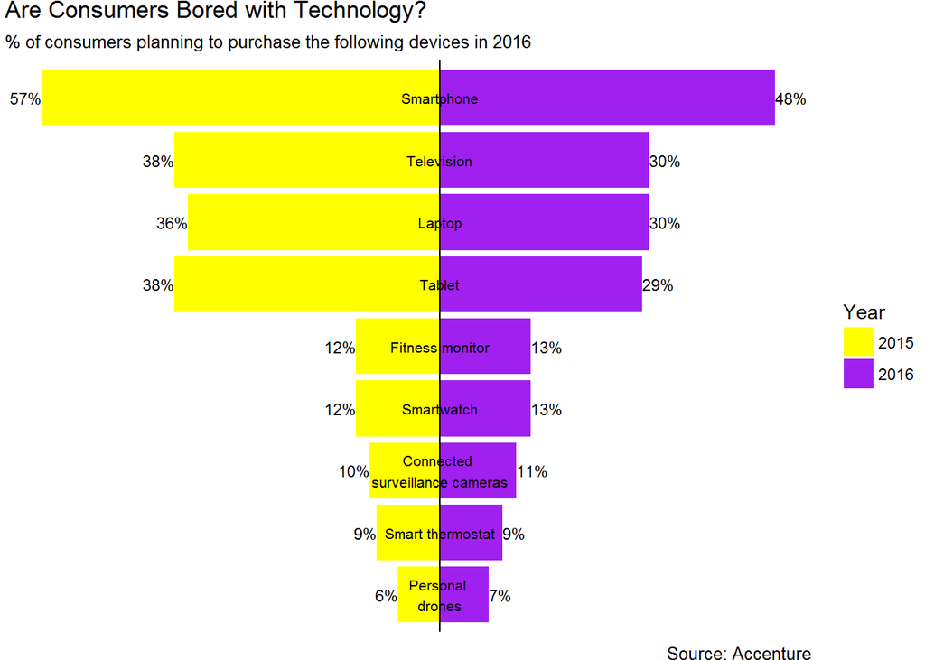

```r
Tech <- bind_rows(Tech2016, Tech2015)
Tech$Product <- factor(Tech$Product, levels = Tech$Product)
attach(Tech)

# Diverging Barcharts
ggplot(Tech, aes(x=Product, y=Purchase.Intent.Rate, fill = Year)) +
  geom_bar(stat='identity') +
  geom_hline(yintercept = 0) +
  labs(title = "Are Consumers Bored with Technology?",
       subtitle = "% of consumers planning to purchase the following devices in 2016",
       caption = "Source: Accenture") +
  scale_fill_manual(name="Year",
                    labels = c("2015", "2016"),
                    values = c("2015"="yellow", "2016"="purple")) +
  geom_text(data = filter(Tech, Year=="2015"), aes(label = Product), position = position_stack(vjust = 1), size = 2.8) +
  geom_text(data = filter(Tech, Year=="2015"), aes(label = percent(abs(Purchase.Intent.Rate)/100)), size = 3, hjust=1) +
  geom_text(data = filter(Tech, Year=="2016"), aes(label = percent(abs(Purchase.Intent.Rate)/100)), size = 3, hjust=0) +
  theme_classic() +
  theme_void() +
  coord_flip()
```

# Graph 2

This last infographic looks at Stephen Curry’s shot selection through mid-way of the 2015 NBA season, which is meant to demonstate that Curry is not a big fan of taking mid-range jumpers. However, the original graph lacks the ability to call out those distances well enough, which are known as the “Dreaded-Twos” distances. Thus, the best solution would be to highlight what distances fall under this category as a way to accentuate on the point being made about Curry’s shot selection.

[figure not shown]

Infographics

```r
DATA <- read.csv("NBA Savant - Stephen Curry Shots.csv", header = TRUE)
attach(DATA)
summary(DATA)
```

```
##             name                     team_name        game_date
##  Stephen Curry:666   Golden State Warriors:666   14/11/2015: 31
##                                                  11/12/2015: 27
##                                                  31/10/2015: 27
##                                                  27/10/2015: 26
##                                                  12/11/2015: 25
##                                                  05/12/2015: 24
##                                                  (Other)   :506
##      season     espn_player_id    team_id           espn_game_id
##  Min.   :2015   Min.   :3975   Min.   :1.611e+09   Min.   :400827890
##  1st Qu.:2015   1st Qu.:3975   1st Qu.:1.611e+09   1st Qu.:400828007
##  Median :2015   Median :3975   Median :1.611e+09   Median :400828101
##  Mean   :2015   Mean   :3975   Mean   :1.611e+09   Mean   :400828132
##  3rd Qu.:2015   3rd Qu.:3975   3rd Qu.:1.611e+09   3rd Qu.:400828238
##  Max.   :2015   Max.   :3975   Max.   :1.611e+09   Max.   :400828443
##
##      period      minutes_remaining seconds_remaining shot_made_flag
##  Min.   :1.000   Min.   : 0.00     Min.   : 0.00     Min.   :0.0000
##  1st Qu.:1.000   1st Qu.: 1.25     1st Qu.:11.00     1st Qu.:0.0000
##  Median :2.000   Median : 4.00     Median :27.00     Median :1.0000
##  Mean   :2.324   Mean   : 4.27     Mean   :27.03     Mean   :0.5105
##  3rd Qu.:3.000   3rd Qu.: 7.00     3rd Qu.:43.00     3rd Qu.:1.0000
##  Max.   :5.000   Max.   :11.00     Max.   :59.00     Max.   :1.0000
##
##                          action_type           shot_type
##  Jump Shot                     :324   2PT Field Goal:305
##  Pullup Jump shot              : 72   3PT Field Goal:361
##  Step Back Jump shot           : 39
##  Layup Shot                    : 32
##  Driving Finger Roll Layup Shot: 29
##  Driving Layup Shot            : 26
##  (Other)                       :144
##  shot_distance                    opponent         x
##  Min.   : 0.000   Sacramento Kings    : 62   Min.   :-241.000
##  1st Qu.: 5.475   New Orleans Pelicans: 53   1st Qu.: -83.250
##  Median :22.600   Brooklyn Nets       : 48   Median :   4.000
##  Mean   :17.142   Toronto Raptors     : 47   Mean   :   2.428
##  3rd Qu.:25.100   Denver Nuggets      : 44   3rd Qu.:  98.500
##  Max.   :46.900   Charlotte Hornets   : 39   Max.   : 240.000
##                   (Other)             :373
##        y            dribbles        touch_time            defender_name
##  Min.   :-21.0   Min.   : 0.000   Min.   : 0.000                 : 27
##  1st Qu.: 21.0   1st Qu.: 0.000   1st Qu.: 0.800   Walker, Kemba : 25
##  Median :122.5   Median : 2.000   Median : 2.550   Rondo, Rajon  : 24
##  Mean   :123.8   Mean   : 3.444   Mean   : 3.682   Jack, Jarrett : 21
##  3rd Qu.:214.0   3rd Qu.: 6.000   3rd Qu.: 5.575   Joseph, Cory  : 17
##  Max.   :712.0   Max.   :24.000   Max.   :19.900   Bradley, Avery: 14
##                                                    (Other)       :538
##  defender_distance   shot_clock
##  Min.   : 0.000    Min.   : 0.00
##  1st Qu.: 2.500    1st Qu.:10.22
##  Median : 3.900    Median :14.90
##  Mean   : 4.015    Mean   :13.75
##  3rd Qu.: 5.300    3rd Qu.:18.40
##  Max.   :17.100    Max.   :24.00
##
```

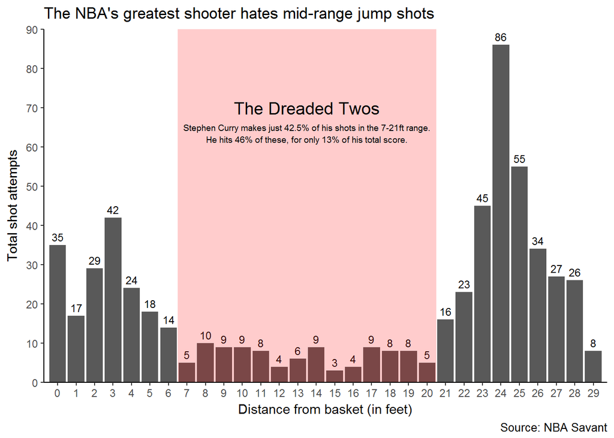

```r
for (i in 1:29){
  if (i==1){
    shot <- DATA %>%
        filter(shot_distance < i) %>%
        summarise(shot_attempts = sum(table(shot_distance < i)))
    shot_i <- DATA %>%
        filter(shot_distance > i, shot_distance < i+1) %>%
        summarise(shot_attempts = sum(table(shot_distance > i & shot_distance < i+1)))
    shot_attempts <- rbind(shot, shot_i)
  }
  else {
    shot_i <- DATA %>%
      filter(shot_distance > i, shot_distance < i+1) %>%
      summarise(shot_attempts = sum(table(shot_distance > i & shot_distance < i+1)))
    shot_attempts <- rbind(shot_attempts, shot_i)
  }
}

shot_distance <- 0:29
shots <- cbind(shot_distance, shot_attempts)

p <- ggplot(data = shots,
            aes(x = shot_distance,
                y = shot_attempts))
p + geom_bar(stat = "identity") +
  labs(title = "The NBA's greatest shooter hates mid-range jump shots",
       caption = "Source: NBA Savant") +
  xlab("Distance from basket (in feet)") +
  ylab("Total shot attempts") +
  scale_x_continuous(breaks = seq(0, 29, 1), expand = c(0.01,0)) +
  scale_y_continuous(limits = c(0,90), breaks = seq(0, 90, 10), expand = c(0,0)) +
  geom_text(aes(label = shot_attempts), size = 3, vjust=-0.5) +
  annotate("rect", xmin=6.5, xmax=20.5, ymin=0, ymax=Inf, alpha=0.2, fill="red")  +
  annotate("text", x = 13.5, y = 70, label = "The Dreaded Twos", size = 5) +
  annotate("text", x = 13.5, y = 65, label = "Stephen Curry makes just 42.5% of his shots in the 7-21ft range.", size = 2.5) +
  annotate("text", x = 13.5, y = 62, label = "He hits 46% of these, for only 13% of his total score.", size = 2.5) +
  theme_classic()
```